# 02 - Intro to R/RStudio + git/GitHub

August 31, 2017

## Course info

## Follow up from last time…

- Office hours:
  - Dr. Cetinkaya-Rundel: Mondays 1 - 3pm + Wednesdays by appt (213 Old Chem)
  - Kyle: Wed 9 - 10am + Fri 10 - 11am at Old Chem 211A
- Course website:
  - http://www2.stat.duke.edu/courses/Fall17/sta112.01/
  - Review the syllabus page for exam and HW due dates
  - Mini HWs will be added as we go

## Goals

## Questions to answer by the end of class

- What is reproducible data analysis, and why do we care?
- What is version control, and why do we care?
- What is R vs RStudio?
- What is git vs GitHub (and do I need to care)?

## Reproducibility

## Reproducibility: who cares?

- [Science retracts gay marriage paper without agreement of lead author LaCour](http://news.sciencemag.org/policy/2015/05/science-retracts-gay-marriage-paper-without-lead-author-s-consent)
  - Two Berkeley grad students who attempted to replicate the study quickly discovered that the data must have been faked.
- [Seizure study retracted after authors realize data got "terribly mixed"](http://retractionwatch.com/2013/02/01/seizure-study-retracted-after-authors-realize-data-got-terribly-mixed/)
- [Bad spreadsheet merge kills depression paper, quick fix resurrects it](http://retractionwatch.com/2014/07/01/bad-spreadsheet-merge-kills-depression-paper-quick-fix-resurrects-it/)
  - Original conclusion: Lower levels of CSF IL-6 were associated with current depression and with future depression […].
  - Revised conclusion: Higher levels of CSF IL-6 and IL-8 were associated with current depression […].

## Reproducibility: why should we care?

**Two-pronged approach**

#1 Convince researchers to adopt a reproducible research workflow

#2 Train new researchers who don’t have any other workflow

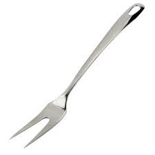

## Reproducible data analysis

- Scriptability \(\rightarrow\) R
- Literate programming \(\rightarrow\) R Markdown
- Version control \(\rightarrow\) Git / GitHub

## Scripting and literate programming

## Donald Knuth "Literate Programming (1983)"

- These ideas have been around for years!
- and tools for putting them to practice have also been around
- but they have never been as accessible as the current tools

## Reproducibility checklist

Near-term goals:

- Are the tables and figures reproducible from the code and data?
- Does the code actually do what you think it does?
- In addition to what was done, is it clear **why** it was done? (e.g., how were parameter settings chosen?)

Long-term goals:

- Can the code be used for other data?
- Can you extend the code to do other things?

## Toolkit

## Toolkit

[figure not shown]

## Demo

## Logging on to RStudio

- Go to https://vm-manage.oit.duke.edu/containers/rstudio
- Log on with your Net ID and password

## Live R/RStudio demo

- R as a calculator

```r
2 + 2
```

```
## [1] 4
```

```r
factorial(20)
```

```
## [1] 2.432902e+18
```

- Working with variables

```r
x = 2
x * 3
```

```
## [1] 6
```

## Collaboration

## How do we collaborate?

- The statistical programming language we'll use is R
- The software we use to interface with R is RStudio
- But how do I get you the course materials that you can build on for your assignments?
  - Hint: I'm not going to email you documents, that would be a mess!

## The complete toolkit

[figure not shown]

## GitHub live demo

- Follow the link to create a repository on GitHub
- Connect an R project to Github repository
- Working with a local and remote repository
- Staging, Committing, Pushing and Pulling

(There is just a bit more of GitHub that we'll use in this class, but for today this is enough.)

## Documenting and reporting

## R Markdown

- Fully reproducible reports
- Simple markdown syntax for text
- Code goes in chunks

**Tip**: Keep the R Markdown cheat sheet and Markdown Quick Reference (Help -> Markdown Quick Reference) handy, we'll refer to it often as the course progresses.

[Live demo – follow along]

## On to data analysis

## Exercises

- Exercise 0
  - Load any necessary packages and data
- Exercise 1
  - Visualize the relationship between life expectancy and GDP per capita in 2007 using a scatter plot.
- Exercise 2
  - Repeat the visualization from Exercise 1, but now color the points by continent.

## Step 0: Load necessary packages

Packages are the fundamental units of reproducible R code. They include reusable R functions, the documentation that describes how to use them, and sample data.

- In the following exercises we'll use the `readr` (for loading data), `dplyr` (for data wrangling), and `ggplot2` (for visualization) packages.
- To use these packages, we must first load in our markdown file

```r
library(dplyr)
library(ggplot2)
library(readr)
```

## Step 1: Load data

```r
gapminder = read_csv("https://stat.duke.edu/~mc301/data/gapminder.csv")
```

## Step 2: Subset data

- Start with the `gapminder` dataset
- Filter for cases (rows) where year is equal to 2007
- Save this new subsetted dataset as `gap07`

```r
gap07 <- gapminder %>%
  filter(year == 2007)
```

## Step 3: Explore and visualize

**Task:** Visualize the relationship between `gdpPercap` and `lifeExp`.

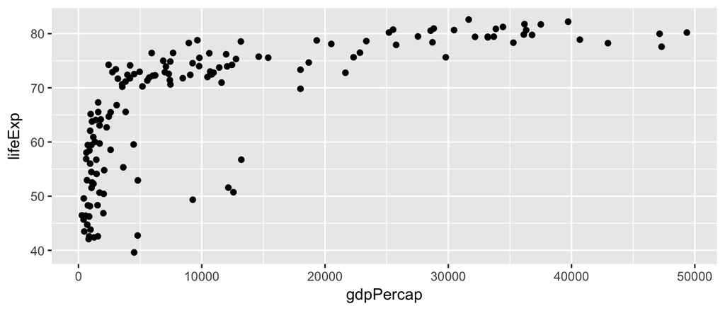

```r
ggplot(data = gap07, aes(x = gdpPercap, y = lifeExp)) +
  geom_point()
```

## Step 4: Dig deeper

**Task:** Color the points by continent.

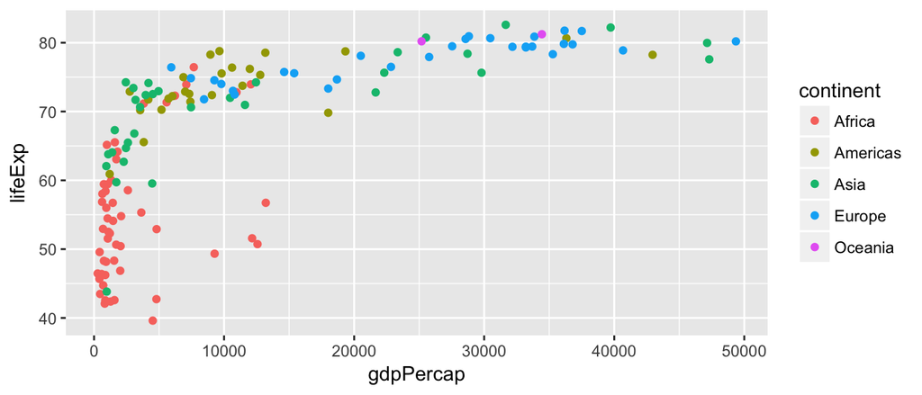

```r
ggplot(data = gap07, aes(x = gdpPercap, y = lifeExp, color = continent)) +
  geom_point()
```

## Update your analysis

What if you wanted to now change your analysis

- to subset for 1952
- plot life expectancy (`lifeExp`) vs. population (`pop`)
- and size the points by GPD (`gpdPercap`)
  - hint: add argument `size = gpdPercap` to your plotting code

## Version control with GitHub

## Version control

- We introduced GitHub as a platform for collaboration
- But it's much more than that…
- It's actually desiged for version control

## Why version control?

[figure not shown]

PhD Comics

## Why version control?

- Simple formal system for tracking all changes to a project
- Time machine for your projects
  - Remove the fear of breaking things
- Learning curve is a bit steep, but when you need it you *REALLY* need it

> Your closest collaborator is you six months ago, but you don’t reply to emails.

– Paul Wilson, UW-Madison

[figure not shown]

## Recap

## Can you answer these questions?

- What is reproducible data analysis, and why do we care?
- What is version control, and why do we care?
- What is R vs RStudio?
- What is git vs GitHub (and do I need to care)?

## Before next class

- Readings for next Tuesday posted
- A brief mini homework will be posted tonight, you'll receive a link to create your repo (just like we did today) and complete a short data visualization task using an R Markdown file I provide
  - Having difficulty? Ask on Slack or come to office hours!